# Donald Trump Speeches Sentiment Analysis- Rohan Chouthai

How exactly did Donald Trump surprise the world and became the President of US? Let us take a look at what is it that he said to the people of US that appealed the most to them.

Let us load the libraries we are going to use.

```r
suppressWarnings(library(readr))
suppressWarnings(library(tidyverse))
suppressWarnings(library(stringr))
suppressWarnings(library(tidytext))
suppressWarnings(library(tm))
```

Now, let us start by loading the text file of Trump’s speeches.

```r
Trump_speeches<-read_lines("C:/Users/rohan/Desktop/DMP/Assignment 3/full_speech.txt")
```

Create a corpus of all the speeches in the text file

```r
Trump_corpus<-VCorpus(VectorSource(Trump_speeches))
print(Trump_corpus)
```

```
<<VCorpus>>
Metadata:  corpus specific: 0, document level (indexed): 0
Content:  documents: 74
```

We need to first clean the speeches of the common stop words, white spaces and punctuation marks.

Let us start of by converting all the upper case letters to lower case letters.

```r
Trump_corpus_clean<-tm_map(Trump_corpus,content_transformer(tolower))
```

Let us now continue to remove all the numbers.

```r
Trump_corpus_clean<-tm_map(Trump_corpus_clean,removeNumbers)
```

Next, we will remove all the stop words.

```r
Trump_corpus_clean<-tm_map(Trump_corpus_clean,removeWords,stopwords())
```

We also want to remove the word “Applause”. Let us do that now.

```r
Trump_corpus_clean<-tm_map(Trump_corpus_clean,removeWords,"applause")
```

Let us now move forward and remove the punctuation marks.

```r
Trump_corpus_clean<-tm_map(Trump_corpus_clean,removePunctuation)
```

```r
library(SnowballC)
#Trump_corpus_clean<-tm_map(Trump_corpus_clean,stemDocument)
```

Finally, let us remove the white spaces in our corpus.

```r
Trump_corpus_clean<-tm_map(Trump_corpus_clean,stripWhitespace)
```

Let us now make a Document Term Matrix of our corpus.

```r
Trump_dcm<-DocumentTermMatrix(Trump_corpus_clean)
Trump_dcm
```

```
<<DocumentTermMatrix (documents: 74, terms: 8193)>>
Non-/sparse entries: 53339/552943
Sparsity           : 91%
Maximal term length: 22
Weighting          : term frequency (tf)
```

Now, let us remove the sparce terms from our DCM.

```r
Trump_dcm_sparce<-removeSparseTerms(Trump_dcm,.5)
Trump_final<-as.data.frame(as.matrix(Trump_dcm_sparce))
dim(Trump_final)
```

```
[1]  74 300
```

```r
Trump_final[,1:10]
```

|  | accomplish | across | administration | africanamerican | ago | also | always | amazing | amendment | america |
| --- | --- | --- | --- | --- | --- | --- | --- | --- | --- | --- |
| 1 | 0 | 2 | 2 | 0 | 4 | 1 | 4 | 1 | 2 | 6 |
| 2 | 0 | 0 | 1 | 0 | 0 | 2 | 0 | 0 | 0 | 5 |
| 3 | 0 | 0 | 6 | 0 | 1 | 11 | 4 | 0 | 0 | 18 |
| 4 | 0 | 1 | 2 | 0 | 1 | 7 | 0 | 0 | 1 | 17 |
| 5 | 0 | 5 | 1 | 2 | 1 | 8 | 1 | 2 | 0 | 18 |
| 6 | 0 | 5 | 3 | 0 | 0 | 7 | 1 | 0 | 0 | 13 |
| 7 | 0 | 0 | 3 | 0 | 1 | 5 | 1 | 5 | 4 | 3 |
| 8 | 1 | 3 | 3 | 2 | 3 | 8 | 2 | 3 | 2 | 26 |
| 9 | 0 | 0 | 0 | 0 | 13 | 6 | 2 | 1 | 1 | 1 |
| 10 | 1 | 2 | 0 | 0 | 9 | 5 | 4 | 0 | 3 | 6 |

[output cut: 64 more lines]

Now let us plot the 15 most common words that featured in Trump’s speeches.

```r
Most_common<-colSums(Trump_final)
sort(Most_common,decreasing = TRUE)[1:15]
```

```
    will    going   people  country  hillary  clinton     jobs american      one     know    great  america      new
    2522     1985     1421     1154      999      899      805      796      770      688      666      632      583
    said     just
     579      574
```

We will make a wordcloud of these words now.

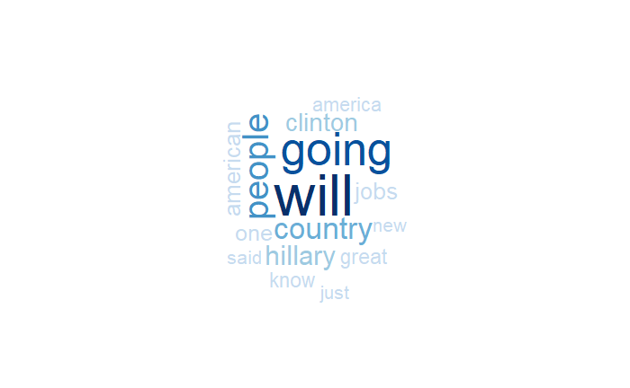

```r
wordcloud::wordcloud(names(Most_common),Most_common,random.order = FALSE,max.words = 15,colors = blues9)
```

Now, let us get the word frequencies in a dataframe so that we can plot them.

```r
Word_freq<-as.data.frame(Most_common)
head(Word_freq)
```

|  | Most_common |
| --- | --- |
| accomplish | 51 |
| across | 102 |
| administration | 191 |
| africanamerican | 148 |
| ago | 120 |
| also | 435 |

```r
Word_freq$Word<-rownames(Word_freq)
rownames(Word_freq)<-c()
Word_freq<-Word_freq[c(2,1)]
colnames(Word_freq)<-c("Word","Frequency")
head(Word_freq)
```

|  | Word | Frequency |
| --- | --- | --- |
| 1 | accomplish | 51 |
| 2 | across | 102 |
| 3 | administration | 191 |
| 4 | africanamerican | 148 |
| 5 | ago | 120 |
| 6 | also | 435 |

```r
Word_freq$Word<-as.factor(Word_freq$Word)
```

```r
str(Word_freq)
```

```
'data.frame':   300 obs. of  2 variables:
 $ Word     : Factor w/ 300 levels "accomplish","across",..: 1 2 3 4 5 6 7 8 9 10 ...
 $ Frequency: num  51 102 191 148 120 435 72 91 89 632 ...
```

```r
Top_15<-Word_freq[1:15,]
dim(Top_15)
```

```
[1] 15  2
```

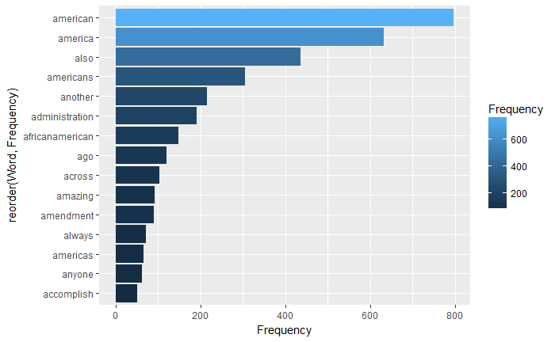

```r
ggplot(Top_15)+geom_bar(mapping = aes(reorder(Word,Frequency),Frequency,fill=Frequency),stat = "identity")+coord_flip()
```

PART B

For the part A, I have used the corpus format. Now, I will use the tidytext format.

```r
Trump_s<-tibble(line=1:length(Trump_speeches),text=Trump_speeches)
Trump_s
```

| line | text |
| --- | --- |
| 1 | Trump: Wow. Whoa. That is some group of people. Thousands. So nice, thank you very much. That's really nice. Thank you. It's great to be at Trump Tower. It's great to be in a wonderful city, New York.… |
| 2 | Good evening. Thank you very much. I speak to you today as a lifelong supporter and true friend of Israel. I'm a newcomer to politics, but not to backing the Jewish state. In 2001, weeks after the att… |
| 3 | Thank you for the opportunity to speak to you, and thank you to the Center for the National Interest for honoring me with this invitation. I would like to talk today about how to develop a new foreign… |
| 4 | Thank you for joining me today. This was going to be a speech on Hillary Clinton and how bad a President, especially in these times of Radical Islamic Terrorism, she would be. Even her former Secret S… |
| 5 | Today I'd like to share my thoughts about the stakes in this election. People have asked me why I am running for President. I have built an amazing business that I love and I get to work side-by-side … |
| 6 | Thank you. I'd like to thank Chairman Jeff Miller for his leadership on behalf of those who have served this country in military uniform, and for working with our campaign on developing real solutions… |
| 7 | Thank you, everybody. Great honor. Great honor, thank you. This is a wonderful day. Aww. [Chants of Trump, Trump, Trump] Wow. On a Saturday morning yet. Isn't that nice? Thank you, all. And we're goin… |
| 8 | Friends, delegates and fellow Americans: I humbly and gratefully accept your nomination for the presidency of the United States. U.S.A.! U.S.A.! U.S.A.! Together, we will lead our party back to the Wh… |
| 9 | Donald Trump. So, it's been 235 days since crooked Hillary Clinton has had a press conference. And you, as reporters who give her all of these glowing reports, should ask yourselves why. And I'll tell… |
| 10 | So how good is he? How good is he? [applause] Special. Special. He is a special man and special person. And he has become my friend. Oh, there is a lot of people here. Whoa. [applause] Hello, everybod… |

[output cut: 64 more lines]

```r
dim(Trump_s)
```

```
[1] 74  2
```

Now, let us tidy the data.

```r
tidy_speeches<-Trump_s%>% unnest_tokens(word,text)
tidy_speeches
```

| line | word |
| --- | --- |
| 1 | trump |
| 1 | wow |
| 1 | whoa |
| 1 | that |
| 1 | is |
| 1 | some |
| 1 | group |
| 1 | of |
| 1 | people |
| 1 | thousands |

[output cut: 990 more lines]

Now, let us first see the most common words. This is essentially an easier way to solve the problem 6.

Before we proceed, let us first remove the common stop words.

```r
new_list<-c("Applause")
new_list<-as.data.frame(new_list)
new_list$lexicon<-c("SMART")
colnames(new_list)<-c("word","lexicon")
new_list$word<-as.character(new_list$word)
stop_words<-rbind(stop_words,new_list)
tidy_speeches_imp<-tidy_speeches%>% anti_join(stop_words,by="word")%>% count(word,sort = TRUE)
tidy_speeches_final<-tidy_speeches_imp[-3,] #removing the word applause
colnames(tidy_speeches_final)<-c("Word_used","n")
```

Now, let us plot the top 15 most used words.

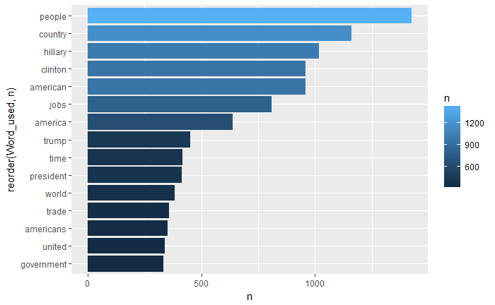

```r
Top15_words<-tidy_speeches_final[1:15,]
ggplot(Top15_words)+geom_bar(mapping = aes(reorder(Word_used,n),n,fill=n),stat = "identity")+coord_flip()
```

Now, let us create a bigram of the Trump speeches. We will do so to get a deeper context in which the words were actually used.

```r
Trump_bigrams<-Trump_s%>% unnest_tokens(bigram,text,token = "ngrams",n=2)
Trump_bigrams
```

| line | bigram |
| --- | --- |
| 1 | trump wow |
| 1 | wow whoa |
| 1 | whoa that |
| 1 | that is |
| 1 | is some |
| 1 | some group |
| 1 | group of |
| 1 | of people |
| 1 | people thousands |
| 1 | thousands so |

[output cut: 990 more lines]

```r
tidy_speeches_big<-tidy_speeches%>% anti_join(stop_words,by="word")
str(tidy_speeches_big)
```

```
Classes tbl_df, tbl and 'data.frame':   85814 obs. of  2 variables:
 $ line: int  1 1 1 1 1 1 1 1 1 1 ...
 $ word: chr  "trump" "wow" "whoa" "people" ...
```

```r
str(Trump_s)
```

```
Classes tbl_df, tbl and 'data.frame':   74 obs. of  2 variables:
 $ line: int  1 2 3 4 5 6 7 8 9 10 ...
 $ text: chr  "Trump: Wow. Whoa. That is some group of people. Thousands. So nice, thank you very much. That's really nice. Th"| __truncated__ " Good evening. Thank you very much. I speak to you today as a lifelong supporter and true friend of Israel. I'm"| __truncated__ "Thank you for the opportuni…
```

Now let us check the most common bigrams.

```r
Trump_bigrams<-Trump_bigrams%>%count(bigram,sort = TRUE)
Trump_bigrams
```

| bigram | n |
| --- | --- |
| going to | 1821 |
| of the | 987 |
| we will | 819 |
| we are | 710 |
| in the | 669 |
| hillary clinton | 663 |
| our country | 575 |
| are going | 558 |
| to be | 538 |
| we have | 473 |

[output cut: 990 more lines]

We can see that there are still stop words in the bigrams which we should eliminate.

For that, we will first split the bigrams into two words, eliminate the stop words and then reunite the words to form a bigram again.

```r
library(tidyr)
Trump_bigrams_sep<-Trump_bigrams%>%separate(bigram,c("word1","word2"),sep = " ")
Trump_bigrams_sep
```

|  | word1 | word2 | n |
| --- | --- | --- | --- |
| 1 | going | to | 1821 |
| 2 | of | the | 987 |
| 3 | we | will | 819 |
| 4 | we | are | 710 |
| 5 | in | the | 669 |
| 6 | hillary | clinton | 663 |
| 7 | our | country | 575 |
| 8 | are | going | 558 |
| 9 | to | be | 538 |
| 10 | we | have | 473 |

[output cut: 990 more lines]

```r
Trump_bigrams_sep<-Trump_bigrams_sep%>% filter(!word1 %in% stop_words$word)%>%filter(!word2 %in% stop_words$word)
Trump_bigrams_sep
```

| word1 | word2 | n |
| --- | --- | --- |
| hillary | clinton | 663 |
| donald | trump | 172 |
| african | american | 164 |
| american | people | 119 |
| trump | administration | 112 |
| hillary | clinton's | 104 |
| trade | deals | 102 |
| november | 8th | 91 |
| middle | east | 88 |
| president | obama | 87 |

[output cut: 990 more lines]

Now let us unite these bigrams again so that we can plot it.

```r
Trump_bigrams_final<-Trump_bigrams_sep%>% unite(bigram,word1,word2,sep = " ")
Trump_bigrams_final
```

|  | bigram | n |
| --- | --- | --- |
| 1 | hillary clinton | 663 |
| 2 | donald trump | 172 |
| 3 | african american | 164 |
| 4 | american people | 119 |
| 5 | trump administration | 112 |
| 6 | hillary clinton's | 104 |
| 7 | trade deals | 102 |
| 8 | november 8th | 91 |
| 9 | middle east | 88 |
| 10 | president obama | 87 |

[output cut: 990 more lines]

Now, let us plot the top 15 most commonly used bigrams in Trump’s speeches.

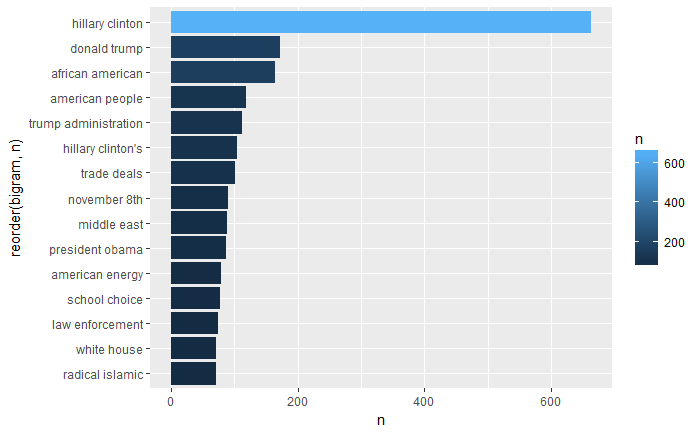

```r
Top15_bigram<-Trump_bigrams_final[1:15,]
ggplot(Top15_bigram)+geom_bar(mapping = aes(reorder(bigram,n),n,fill=n),stat = "identity")+coord_flip()
```

PART C

For the part C, I will do the following:

A sentiment analysis of Donald Trump’s speeches. In order to make sure sentiments are assigned to appropriate contexts, first tokenize the speeches into bigrams, and then filter out all bigrams where the first word is any of “not”, “no”, or “never”.

Now, we have to remove the bigrams where the first words are “no”,“not”,“never”.

For that, let us use the separated bigrams from the previous question.

```r
Negative<-c("no","not","never")
Tr<-c("trump","applause")
Trump_bigram_senti<-Trump_bigrams_sep%>% filter(!word1 %in% Negative)%>% filter(!word2%in% Tr)
Trump_bigram_senti%>% filter(word2=="trump")# checking if the word elimination worked.
```

| word1 | word2 | n |
| --- | --- | --- |

```r
Trump_bigram_senti%>% filter(word1=="no")
```

| word1 | word2 | n |
| --- | --- | --- |

Now let us get each of the 10 sentiments in the nrc into 10 separate dataframes.

We will need these to do the further analysis.

```r
nrc<-get_sentiments("nrc")
unique(nrc$sentiment)
```

```
 [1] "trust"        "fear"         "negative"     "sadness"      "anger"        "surprise"     "positive"     "disgust"
 [9] "joy"          "anticipation"
```

```r
nrc_trust<-nrc%>%filter(sentiment=="trust")
nrc_fear<-nrc%>%filter(sentiment=="fear")
nrc_negative<-nrc%>%filter(sentiment=="negative")
nrc_sadness<-nrc%>%filter(sentiment=="sadness")
nrc_anger<-nrc%>%filter(sentiment=="anger")
nrc_surprise<-nrc%>%filter(sentiment=="suprise")
nrc_positive<-nrc%>%filter(sentiment=="positive")
nrc_disgust<-nrc%>%filter(sentiment=="disgust")
nrc_joy<-nrc%>%filter(sentiment=="joy")
nrc_anticipation<-nrc%>%filter(sentiment=="anticipation")
```

Let us first create a new column in our dataframe so that we can later join the sentiment dataframes.

```r
Trump_bigram_senti$word<-Trump_bigram_senti$word2
Trump_sentiment<-Trump_bigram_senti[,4]
class(Trump_sentiment)
```

```
[1] "tbl_df"     "tbl"        "data.frame"
```

Now, let us see the top 10 words in Trump’s speeches associated with trust.

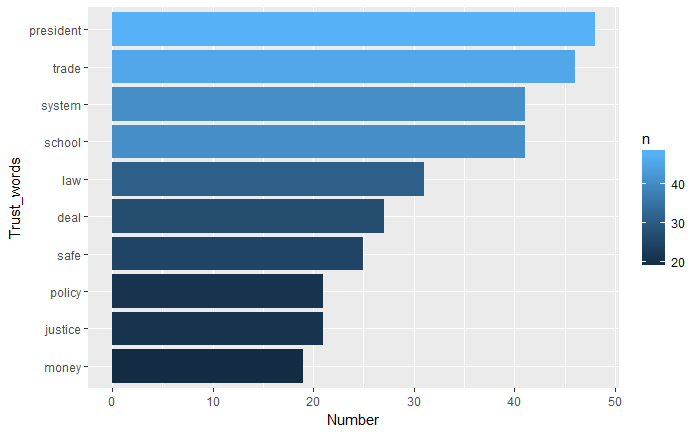

```r
Trust_trump<-Trump_sentiment%>% inner_join(nrc_trust,by="word")%>% count(word)%>%top_n(10)
ggplot(Trust_trump)+geom_bar(mapping = aes(reorder(word,n),n,fill=n),stat = "identity")+coord_flip()+labs(x="Trust_words",y="Number")
```

Now, let us see the top 10 words in Trump’s speeches associated with Fear.

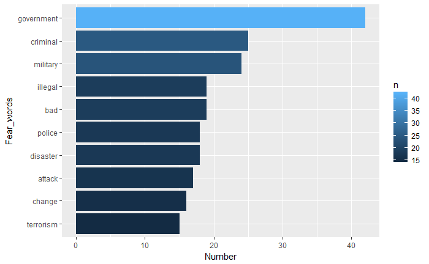

```r
Fear_trump<-Trump_sentiment%>% inner_join(nrc_fear,by="word")%>% count(word)%>%top_n(10)
ggplot(Fear_trump)+geom_bar(mapping = aes(reorder(word,n),n,fill=n),stat = "identity")+coord_flip()+labs(x="Fear_words",y="Number")
```

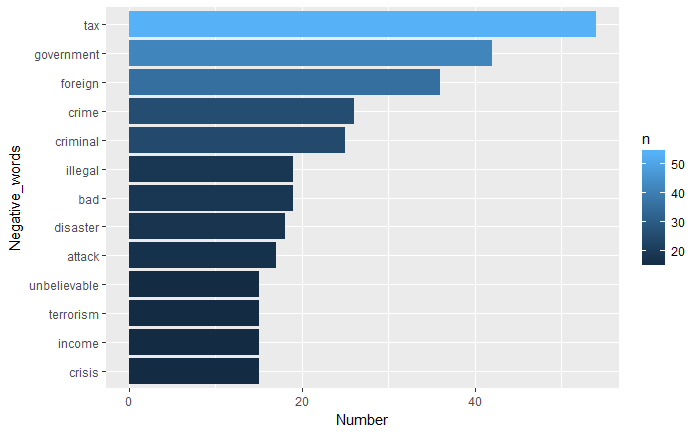

```r
Negative_trump<-Trump_sentiment%>% inner_join(nrc_negative,by="word")%>% count(word)%>%top_n(10)
ggplot(Negative_trump)+geom_bar(mapping = aes(reorder(word,n),n,fill=n),stat = "identity")+coord_flip()+labs(x="Negative_words",y="Number")
```

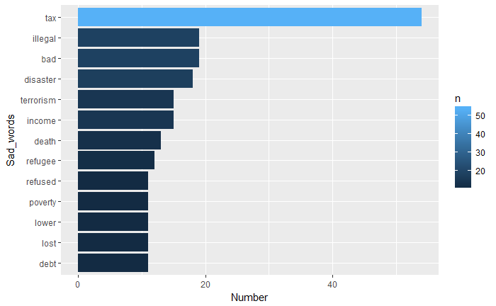

```r
Sad_trump<-Trump_sentiment%>% inner_join(nrc_sadness,by="word")%>% count(word)%>%top_n(10)
ggplot(Sad_trump)+geom_bar(mapping = aes(reorder(word,n),n,fill=n),stat = "identity")+coord_flip()+labs(x="Sad_words",y="Number")
```

Now, let us see the top 10 words in Trump’s speeches associated with anger.

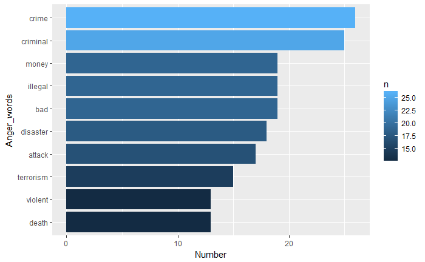

```r
Anger_trump<-Trump_sentiment%>% inner_join(nrc_anger,by="word")%>% count(word)%>%top_n(10)
ggplot(Anger_trump)+geom_bar(mapping = aes(reorder(word,n),n,fill=n),stat = "identity")+coord_flip()+labs(x="Anger_words",y="Number")
```

[figure not shown]

```r
Surprise_trump<-Trump_sentiment%>% inner_join(nrc_surprise,by="word")%>% count(word)%>%top_n(10)
ggplot(Surprise_trump)+geom_bar(mapping = aes(reorder(word,n),n,fill=n),stat = "identity")+coord_flip()+labs(x="Trust_words",y="Number")
```

Now, let us see the top 10 words in Trump’s speeches associated with positive.

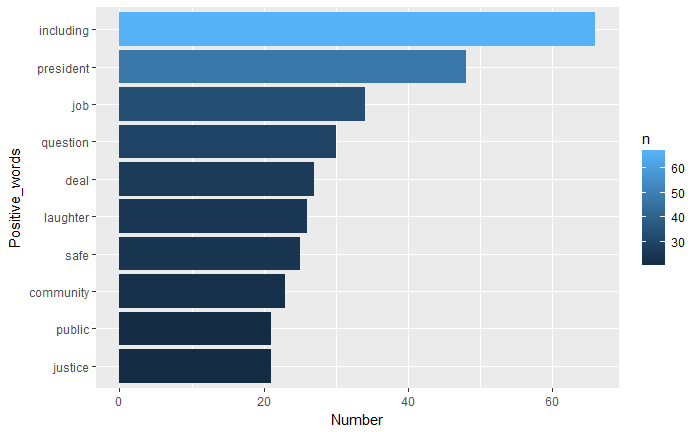

```r
Positive_trump<-Trump_sentiment%>% inner_join(nrc_positive,by="word")%>% count(word)%>%top_n(10)
ggplot(Positive_trump)+geom_bar(mapping = aes(reorder(word,n),n,fill=n),stat = "identity")+coord_flip()+labs(x="Positive_words",y="Number")
```

Now, let us see the top 10 words in Trump’s speeches associated with disgust.

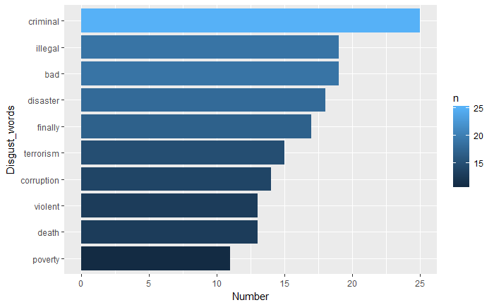

```r
disgust_trump<-Trump_sentiment%>% inner_join(nrc_disgust,by="word")%>% count(word)%>%top_n(10)
ggplot(disgust_trump)+geom_bar(mapping = aes(reorder(word,n),n,fill=n),stat = "identity")+coord_flip()+labs(x="Disgust_words",y="Number")
```

Now, let us see the top 10 words in Trump’s speeches associated with joy.

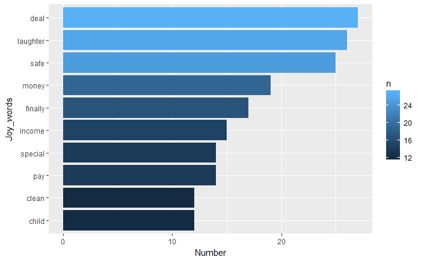

```r
joy_trump<-Trump_sentiment%>% inner_join(nrc_joy,by="word")%>% count(word)%>%top_n(10)
ggplot(joy_trump)+geom_bar(mapping = aes(reorder(word,n),n,fill=n),stat = "identity")+coord_flip()+labs(x="Joy_words",y="Number")
```

Now, let us see the top 10 words in Trump’s speeches associated with anticipation.

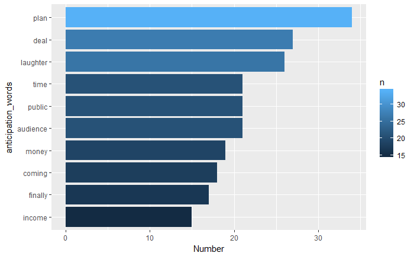

```r
anticipation_trump<-Trump_sentiment%>% inner_join(nrc_anticipation,by="word")%>% count(word)%>%top_n(10)
ggplot(anticipation_trump)+geom_bar(mapping = aes(reorder(word,n),n,fill=n),stat = "identity")+coord_flip()+labs(x="anticipation_words",y="Number")
```

PART D

```r
Text_analysis_corpus<-function(mysrc_clean,nwords){
  mysrc_clean<-tm_map(mysrc_clean,removeNumbers)
  mysrc_clean<-tm_map(mysrc_clean,removeWords,stopwords())
  mysrc_clean<-tm_map(mysrc_clean,removePunctuation)
  library(SnowballC)
  mysrc_clean<-tm_map(mysrc_clean,stripWhitespace)
 mysrc_dcm<-DocumentTermMatrix(mysrc_clean)

 mysrc_sparce<-removeSparseTerms(mysrc_dcm,.5)
mysrc_final<-as.data.frame(as.matrix(mysrc_sparce))
Most_common<-colSums(Trump_final)
Top_words<-sort(Most_common,decreasing = TRUE)[1:nwords]
Word_freq<-as.data.frame(Top_words)
Word_freq$Word<-rownames(Word_freq)
rownames(Word_freq)<-c()
Word_freq<-Word_freq[c(2,1)]
colnames(Word_freq)<-c("Word","Frequency")
Word_freq$Word<-as.factor(Word_freq$Word)
ggplot(Word_freq)+geom_bar(mapping = aes(reorder(Word,Frequency),Frequency,fill=Frequency),stat = "identity")+coord_flip()
 }
```

Let us test if the method works.

We will use the corpus from the question 6.

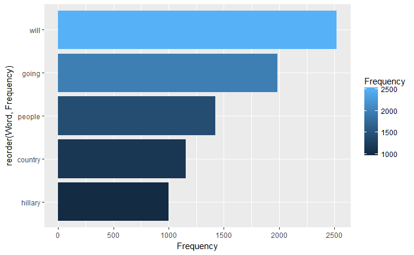

```r
Text_analysis_corpus(Trump_corpus,5)
```